# Team-7-Code

```python
# for numerical type of operations, importing numpy
import numpy as np
# for data manipulation and analysis, importing pandas
import pandas as pd
# for creating visualizations, importing matplotlib library
import matplotlib.pyplot as plt
# for statistical data visualization, importing seaborn library
import seaborn as sns

# Importing clustering algorithms from scikit-learn for unsupervised machine learning tasks
from sklearn.cluster import KMeans, DBSCAN, OPTICS, AgglomerativeClustering
from sklearn.preprocessing import StandardScaler
# Importing the warnings module to manage warning messages during code execution
import warnings
# Suppressing all warning messages to ensure a cleaner output
warnings.filterwarnings("ignore")
```

```python
# Reading a CSV file ('DATASET.csv') into a Pandas DataFrame named 'd_f'
d_f = pd.read_csv('DATASET.csv')
```

```python
# Displaying the first few rows of the DataFrame 'd_f' to inspect the dataset's structure
d_f.head()
```

|  | CustomerID | Gender | Age | Annual Income (k$) | Spending Score (1-100) |
| --- | --- | --- | --- | --- | --- |
| 0 | 1 | Male | 19 | 15 | 39 |
| 1 | 2 | Male | 21 | 15 | 81 |
| 2 | 3 | Female | 20 | 16 | 6 |
| 3 | 4 | Female | 23 | 16 | 77 |
| 4 | 5 | Female | 31 | 17 | 40 |

```python
# Dropping the 'CustomerID' column from the DataFrame 'd_f'
d_f.drop('CustomerID', axis=1, inplace = True)
```

```python
# Displaying the first few rows of the DataFrame 'd_f' after removing the 'CustomerID' column
d_f.head()
```

|  | Gender | Age | Annual Income (k$) | Spending Score (1-100) |
| --- | --- | --- | --- | --- |
| 0 | Male | 19 | 15 | 39 |
| 1 | Male | 21 | 15 | 81 |
| 2 | Female | 20 | 16 | 6 |
| 3 | Female | 23 | 16 | 77 |
| 4 | Female | 31 | 17 | 40 |

```python
# Displaying the dimensions (number of rows and columns) of the DataFrame 'd_f'
d_f.shape
```

```
(200, 4)
```

```python
# Renaming specific columns in the DataFrame 'd_f' for clarity and ease of use
d_f = d_f.rename(columns={'Annual Income (k$)': 'Annual_income', \
                        'Spending Score (1-100)': 'Spending_score'})
```

```python
# Counting missing values per column in the DataFrame 'd_f'
d_f.isna().sum()
```

```
Gender            0
Age               0
Annual_income     0
Spending_score    0
dtype: int64
```

```python
# Displaying summary information about the DataFrame 'd_f'
d_f.info()
```

```
<class 'pandas.core.frame.DataFrame'>
RangeIndex: 200 entries, 0 to 199
Data columns (total 4 columns):
 #   Column          Non-Null Count  Dtype
---  ------          --------------  -----
 0   Gender          200 non-null    object
 1   Age             200 non-null    int64
 2   Annual_income   200 non-null    int64
 3   Spending_score  200 non-null    int64
dtypes: int64(3), object(1)
memory usage: 6.4+ KB
```

```python
# Replacing 'Male' with 0 and 'Female' with 1 in the 'Gender' column of the DataFrame 'd_f'
d_f.Gender.replace('Male', 0, inplace=True)
d_f.Gender.replace('Female', 1, inplace=True)
```

```python
# Displaying the first few rows of the DataFrame 'd_f' after modifications
d_f.head()
```

|  | Gender | Age | Annual_income | Spending_score |
| --- | --- | --- | --- | --- |
| 0 | 0 | 19 | 15 | 39 |
| 1 | 0 | 21 | 15 | 81 |
| 2 | 1 | 20 | 16 | 6 |
| 3 | 1 | 23 | 16 | 77 |
| 4 | 1 | 31 | 17 | 40 |

```python
# Displaying summary statistics for numerical columns in the DataFrame 'd_f'
d_f.describe()
```

|  | Gender | Age | Annual_income | Spending_score |
| --- | --- | --- | --- | --- |
| count | 200.000000 | 200.000000 | 200.000000 | 200.000000 |
| mean | 0.560000 | 38.850000 | 60.560000 | 50.200000 |
| std | 0.497633 | 13.969007 | 26.264721 | 25.823522 |
| min | 0.000000 | 18.000000 | 15.000000 | 1.000000 |
| 25% | 0.000000 | 28.750000 | 41.500000 | 34.750000 |
| 50% | 1.000000 | 36.000000 | 61.500000 | 50.000000 |
| 75% | 1.000000 | 49.000000 | 78.000000 | 73.000000 |
| max | 1.000000 | 70.000000 | 137.000000 | 99.000000 |

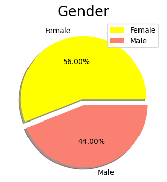

```python
# Creating a pie chart to visualize the distribution of gender in the DataFrame 'df'
labels = ['Female', 'Male']
size = d_f['Gender'].value_counts()
colors = ['yellow', 'salmon']
explode = [0, 0.1]

# Setting up the figure size
plt.rcParams['figure.figsize'] = (4, 4)

# Plotting the pie chart with specified colors, explode, labels, and other parameters
plt.pie(size, colors = colors, explode = explode, \
        labels = labels, shadow = True, autopct = '%.2f%%')

# Adding title and adjusting display options
plt.title('Gender', fontsize = 20)
plt.axis('off')
plt.legend()

# Displaying the pie chart
plt.show()
```

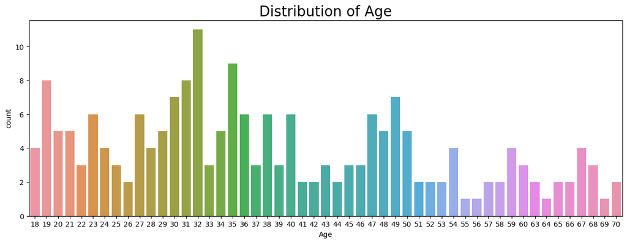

```python
# Setting the default figure size for the upcoming Seaborn countplot
plt.rcParams['figure.figsize'] =(15, 5)
# Creating a countplot to visualize the distribution of 'Age' in the DataFrame 'df' using Seaborn
sns.countplot (d_f[ 'Age'])
# Adding title to the plot
plt.title('Distribution of Age', fontsize = 20)
# Displaying the countplot
plt.show()
```

OBSERVATIONS:(from above chart/graph)

1. It can be seen that the Ages from 27 to 40 are frequently coming to malls and purchasing.
2. People of Age 55, 56, 69, 64 are very less frequent in the Malls.
3. People at Age 32 are the Most Frequent Visitors in the Mall.

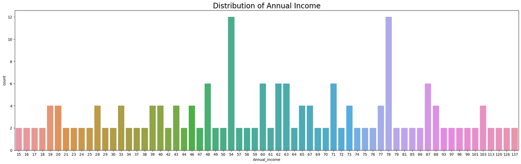

```python
# Setting the default figure size for the upcoming Seaborn countplot
plt.rcParams['figure.figsize'] =(25,7)
# Creating a countplot to visualize the distribution of 'Annual_income' in the DataFrame 'df' using Seaborn
sns.countplot (d_f[ 'Annual_income'])
# Adding title to the plot
plt.title('Distribution of Annual Income', fontsize = 20)
# Displaying the countplot
plt.show()
```

OBSERVATIONS(from above chart/graph):

1. Annual Income of customer rangs from 15k to 137K.
2. There are more Customers in the Mall who have their Annual Income as 54k or 78k.

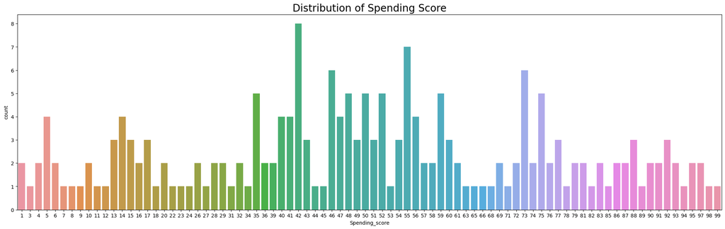

```python
# Setting the default figure size for the upcoming Seaborn countplot
plt.rcParams['figure.figsize'] =(25, 7)
# Creating a countplot to visualize the distribution of 'Spending_score' in the DataFrame 'df' using Seaborn
sns.countplot (d_f[ 'Spending_score'])
# Adding title to the plot
plt.title('Distribution of Spending Score', fontsize = 20)
# Displaying the countplot
plt.show()
```

OBSERVATIONS((from above chart/graph):

In general, we can conclude that most of the Customers have their Spending Score in the range of 35–60.Interesting thing is that there are customers having 1 spending score, and 99 Spending score also, which shows that the mall caters to the variety of customers with varying needs and requirements available in the Mall.

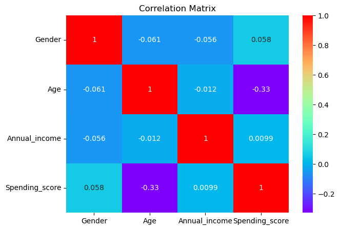

```python
# Creating a heatmap to visualize the Pearson correlation matrix of numerical columns in the DataFrame 'df'
plt.figure(figsize = (7,5))
#default pearson correlation
# Using Seaborn's heatmap with annotations, specifying the 'rainbow' color map
sns.heatmap(d_f.corr(), annot = True, cmap="rainbow")
# Adding a title to the plot
plt.title('Correlation Matrix')
# Displaying the heatmap
plt.show()
```

OBSERVATIONS: There is not much correlation between variables.

```python
#1.Relation between Gender and Spending Score

# Analyzing the relationship between Gender and Spending Score
# Initializing variables to calculate male and female spending scores to Caluclate male and female spending scores
spending_score_male = 0
spending_score_female = 0
# Looping through the DataFrame to calculate spending scores based on gender
for i in range(len(d_f)):
    if d_f['Gender'][i] == 0:
        spending_score_male += d_f['Spending_score'][i]
    if d_f['Gender'][i] == 1:
        spending_score_female += d_f['Spending_score'][i]

# Displaying the calculated spending scores for males and females
print("Males Spending Score: ",spending_score_male)
print("Females Spending Score: ",spending_score_female)
```

```
Males Spending Score:  4269
Females Spending Score:  5771
```

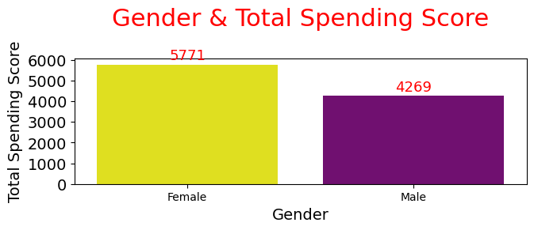

```python
#Gender & Total Spending Score


# Creating a list of total spending scores for females and males
list_genders_spending_score = [int(spending_score_female),\
                               int(spending_score_male)]
# Converting the list to a Pandas Series
series_genders_spending_score = pd.Series(\
                            data = list_genders_spending_score)
# Creating a subplot and plotting a bar chart for Gender & Total Spending Score
plt.subplot(3,3,3)
plots = sns.barplot(x=['Female','Male'], \
        y=series_genders_spending_score, palette=['yellow','purple'])
# Annotating the bar chart with total spending scores
for bar in plots.patches:
    plots.annotate(format(bar.get_height(), '.0f'),\
        (bar.get_x() + bar.get_width() / 2, bar.get_height()),\
        ha='center', va='center',size=13, xytext=(0, 8),\
                   textcoords='offset points',color='red')
# Adding labels, ticks, and title to the plot
plt.xlabel("Gender", size=14)
plt.ylabel("Total Spending Score", size=14)
plt.yticks(np.arange(0,6001,1000),size='14')
plt.grid(False)
plt.title("Gender & Total Spending Score\n", color="red", size='22')
```

[figure not shown]

```python
#Gender & Mean Spending Score
# Analyzing the relationship between Gender and Mean Spending Score

# Creating a list of mean spending scores for females and males
list_genders_spending_score_mean = [int(spending_score_female/d_f\
            ['Gender'].value_counts()[0]),\
            int(spending_score_male/d_f['Gender'].value_counts()[1])]
# Converting the list to a Pandas Series
series_genders_spending_score_mean = pd.Series(data = \
                                    list_genders_spending_score_mean)
# Creating a subplot and plotting a bar chart for Gender & Mean Spending Score
plt.subplot(3,3,3)
plots = sns.barplot(x=['Female','Male'],\
        y=series_genders_spending_score_mean, palette='hsv')

# Annotating the bar chart with mean spending scores
for bar in plots.patches:
    plots.annotate(format(bar.get_height(), '.0f'),\
        (bar.get_x() + bar.get_width() / 2,bar.get_height()),\
        ha='center', va='center',size=13, xytext=(0, 8),\
        textcoords='offset points',color='red')

# Adding labels, ticks, and title to the plot
plt.xlabel("Gender", size=14)
plt.ylabel("Mean Spending Score", size=14)
plt.yticks(np.arange(0,71,10),size='14')
plt.grid(False)
plt.title("Gender & Mean Spending Score\n", color="red", size='22')

# Adjusting layout and displaying the plot
plt.tight_layout()
plt.show()
```

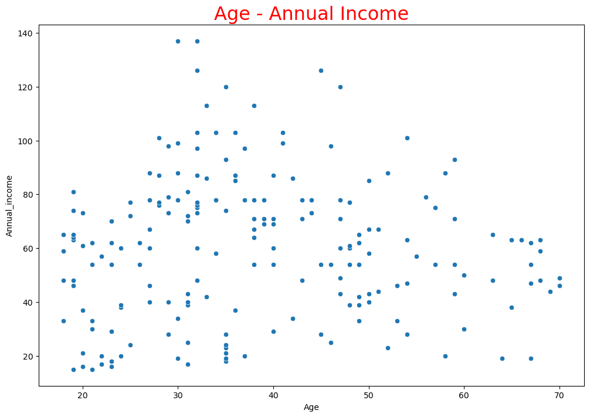

```python
#1.Age and Annual Income

# Visualizing the relationship between Age and Annual Income using a scatter plot
# Setting the figure size for the scatter plot
plt.figure(figsize=(12,8))
# Creating a scatter plot for Age and Annual Income
sns.scatterplot(x = d_f['Age'], y = d_f['Annual_income'])
# Adding a title to the plot
plt.title('Age - Annual Income' ,size = 23, color='red')
```

OBSERVATIONS:

In this graph we can clearly see people in their 30s, 40s and 50s people tend to earn more money annually than people younger than 30 or older than 50.

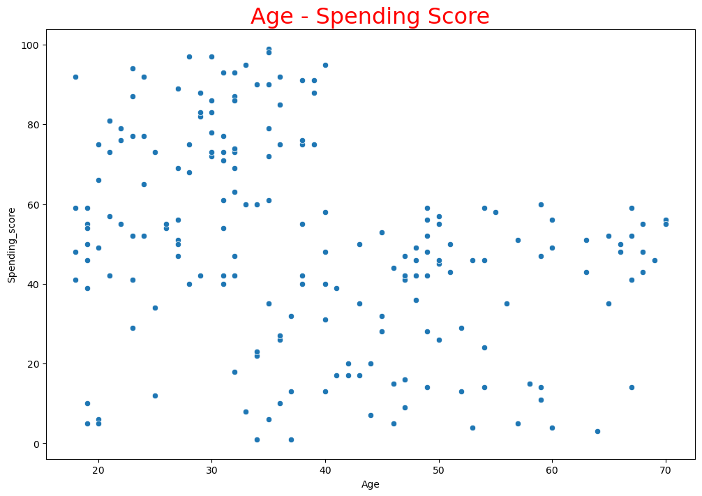

```python
#2.Age and Spending score

# Visualizing the relationship between Age and Spending Score using a scatter plot
# Setting the figure size for the scatter plot
plt.figure(figsize=(12,8))
# Creating a scatter plot for Age and Spending Score
sns.scatterplot(x = d_f['Age'], y = d_f['Spending_score'])
# Adding a title to the plot
plt.title('Age - Spending Score' ,size = 23, color='red')
```

OBSERVATIONS:

In this graph we can see that young people(between the ages of 20-40) tend to spend more than older people. That can be due to many reasons: young people usually have more free time than old people, shopping malls tend to have shops that target young people such as videogames and tech stores, etc. By this we can make our target audience more specific.

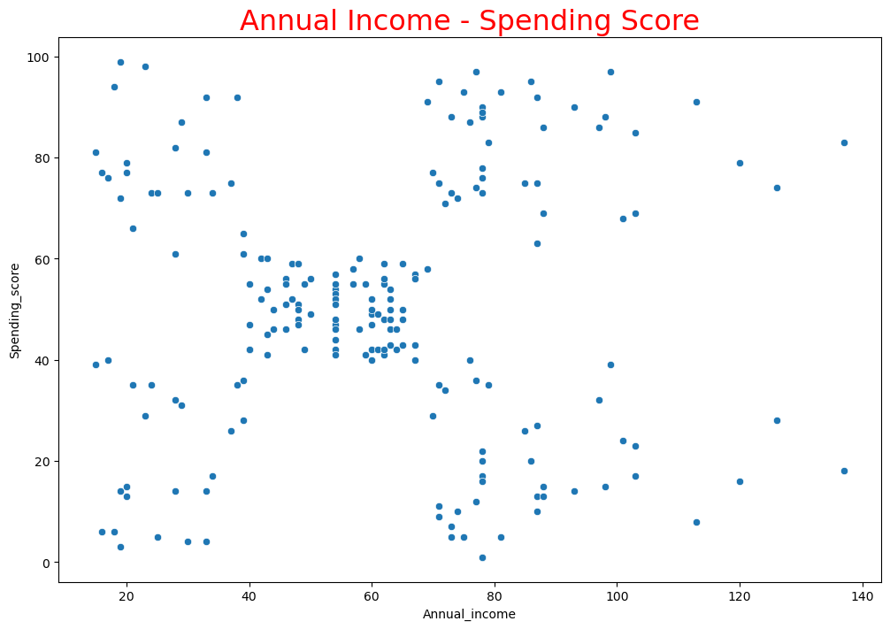

```python
#3.Spending score and Annual Income

# Visualizing the relationship between Annual Income and Spending Score using a scatter plot
# Setting the figure size for the scatter plot
plt.figure(figsize=(12,8))
# Creating a scatter plot for Annual Income and Spending Score
sns.scatterplot(x = d_f['Annual_income'], \
                y = d_f['Spending_score'], palette = "red")
# Adding a title to the plot
plt.title('Annual Income - Spending Score', size = 23, color='red')
```

```python
#BUILDING THE MODEL
#1.Spending score vs Annual Income
#Step1: Finding no.of clusters by Elbow method

#Creating values for the elbow
X1 =d_f[['Spending_score','Annual_income']].values
inertia = []

# Looping through different cluster values to calculate the inertia (Within-Cluster-Sum-of-Squares)
for i in range(1,15):
    means_k = KMeans(n_clusters=i, random_state=0) # Inertia represents WCSS (Within-Cluster-Sum-of-Squares)
    means_k.fit(X1)
    inertia.append(means_k.inertia_)
```

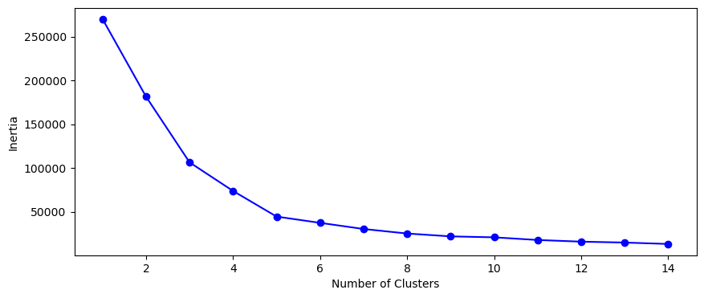

```python
#Plotting the elbow

# Creating a figure for the plot
plt.figure(1 , figsize = (10 ,4))
# Plotting the number of clusters vs. inertia
plt.plot(range (1,15) , inertia,'bo-')
# Adding labels to the axes
plt.xlabel('Number of Clusters') , plt.ylabel('Inertia')
# Displaying the plot
plt.show()
```

OBSERVATIONS:

(Using matplotlib we have plotted the above graph) The elbow method plots the value of the cost function produced by different values of k. In this problem, we are using the inertia as cost function in order to identify the sum of squared distances of samples to the nearest cluster centre. By looking at the graph we can say number of clusters are equal to 5. Therefore we are selecting 5 as the number of clusters to divide our data.

```python
#Step2:Clustering

# Initializing KMeans with the chosen number of clusters (5 in this case)
km1=KMeans(n_clusters=5)

# Fitting the input data to the KMeans model
km1.fit(X1)

# Predicting the labels of the input data points
y=km1.predict(X1)

# Adding a new column 'label' to the DataFrame to store cluster labels
d_f["label"] = y

# Displaying the updated DataFrame with the added 'label' column
d_f.head()
```

|  | Gender | Age | Annual_income | Spending_score | label |
| --- | --- | --- | --- | --- | --- |
| 0 | 0 | 19 | 15 | 39 | 2 |
| 1 | 0 | 21 | 15 | 81 | 3 |
| 2 | 1 | 20 | 16 | 6 | 2 |
| 3 | 1 | 23 | 16 | 77 | 3 |
| 4 | 1 | 31 | 17 | 40 | 2 |

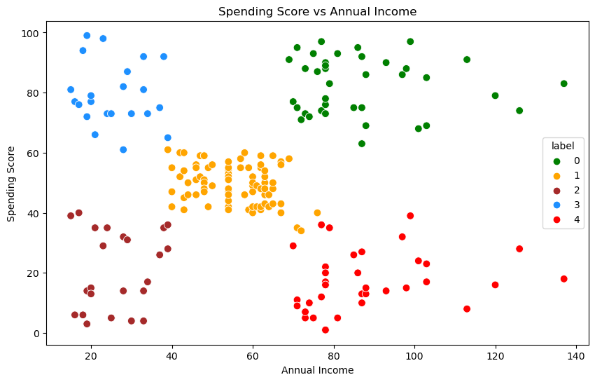

```python
# Visualizing the Clusters in Spending Score vs Annual Income
# Creating a scatter plot with different colors for each cluster

plt.figure(figsize=(10,6))
sns.scatterplot(x = 'Annual_income',y = 'Spending_score',hue="label", \
                palette=['green','orange','brown','dodgerblue','red'], \
                legend='full',data = d_f ,s = 60 )

# Adding labels to the axes
plt.xlabel('Annual Income')
plt.ylabel('Spending Score')

# Adding a title to the plot
plt.title('Spending Score vs Annual Income')

# Displaying the scatter plot
plt.show()
```

OBSERVATIONS:

This Clustering Analysis gives us a very clear insight about the different segments of the customers in the Mall.

Cluster 3: spendtrift customers - earning less but spending more

```python
#2.Age vs Spending score
#Step1: Finding the number of clusters using the Elbow method

#Creating values for the elbow
x = d_f[['Age','Spending_score']].values
inertia = []

# Looping through different cluster values to calculate the inertia
for i in range(1,11):
    means_k = KMeans(n_clusters=i, random_state=88)
    means_k.fit(x)
    inertia.append(means_k.inertia_)
```

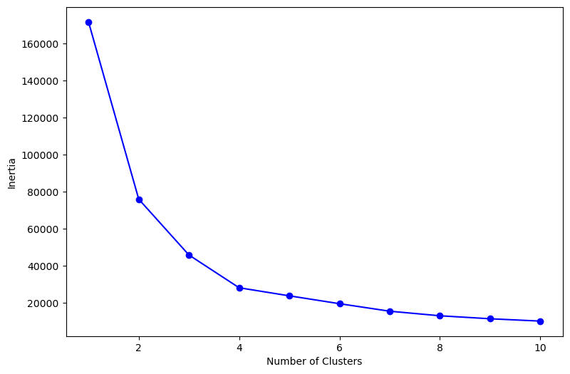

```python
# Plotting the Elbow Method for Age vs Spending Score

# Creating a figure for the plot
plt.figure(figsize = (9 ,6))
# Plotting the number of clusters vs. inertia
plt.plot(range (1,11) , inertia,'bo-')
# Adding labels to the axes
plt.xlabel('Number of Clusters') , plt.ylabel('Inertia')
# Displaying the plot
plt.show()
```

```python
#Step2: Clustering

# Initializing KMeans with the chosen number of clusters (4 in this case)
km=KMeans(n_clusters=4)
# Fitting the input data to the KMeans model
km.fit(x)
#predicting the labels of the input data points
y=km.predict(x)
# Adding a new column 'label' to the DataFrame to store cluster labels
d_f["label"] = y
# Displaying the updated DataFrame with the added 'label' column
d_f.head()
```

|  | Gender | Age | Annual_income | Spending_score | label |
| --- | --- | --- | --- | --- | --- |
| 0 | 0 | 19 | 15 | 39 | 0 |
| 1 | 0 | 21 | 15 | 81 | 2 |
| 2 | 1 | 20 | 16 | 6 | 1 |
| 3 | 1 | 23 | 16 | 77 | 2 |
| 4 | 1 | 31 | 17 | 40 | 0 |

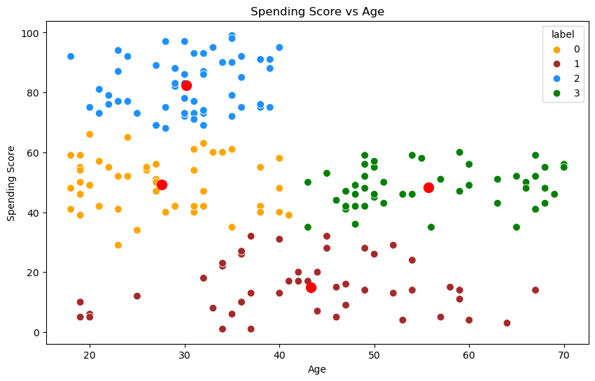

```python
# Visualizing the Clusters in Age vs Spending Score

# Creating a scatter plot with different colors for each cluster
plt.figure(figsize=(10,6))
sns.scatterplot(x = 'Age',y = 'Spending_score',hue="label",\
                palette=['orange','brown','dodgerblue','green'], \
                legend='full',data = d_f ,s = 60 )
# Plotting cluster centers in red
plt.scatter(km.cluster_centers_[:, 0], \
            km.cluster_centers_[:, 1], s = 100, c = 'red')

# Adding labels to the axes
plt.xlabel('Age')
plt.ylabel('Spending Score')

# Adding a title to the plot
plt.title('Spending Score vs Age')

# Displaying the scatter plot
plt.show()
```

OBSERVATIONS:

Cluster 3: Age above 40(old) and spending score Average.

```python
# Feature scaling
scaler = StandardScaler()
d_f_scaled = scaler.fit_transform(d_f[['Annual_income', 'Spending_score']])
```

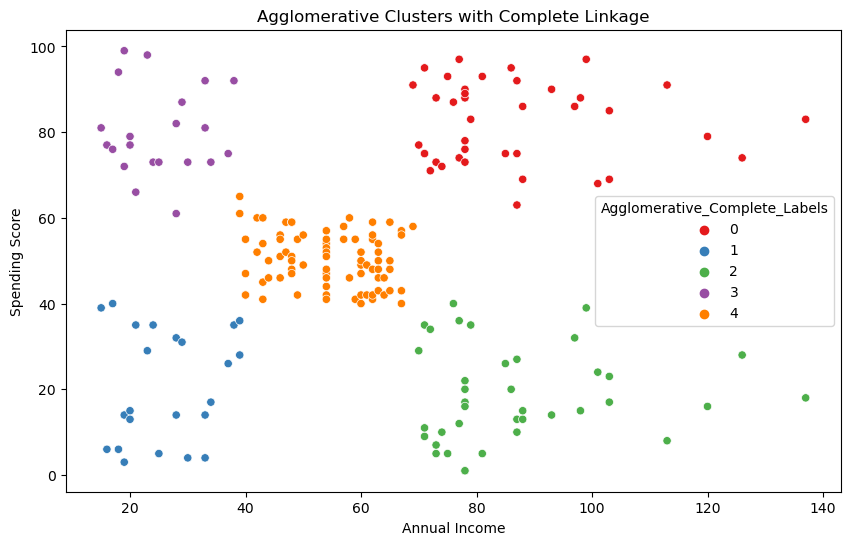

```python
# Agglomerative clustering with complete-linkage criterion

# Initializing AgglomerativeClustering with the chosen number of clusters (5 in this case) and 'complete' linkage
agglomerative_complete = AgglomerativeClustering(n_clusters=5, linkage='complete')
# Assigning cluster labels to the DataFrame using Agglomerative Clustering with complete linkage
d_f['Agglomerative_Complete_Labels'] = agglomerative_complete.fit_predict(d_f_scaled)

# Visualizing Agglomerative Clusters with complete linkage

# Creating a scatter plot with different colors for each Agglomerative cluster with complete linkage
plt.figure(figsize=(10, 6))
sns.scatterplot(x='Annual_income', y='Spending_score', hue='Agglomerative_Complete_Labels', palette='Set1', data=d_f)
# Adding title and labels to the axes
plt.title('Agglomerative Clusters with Complete Linkage')
plt.xlabel('Annual Income')
plt.ylabel('Spending Score')
plt.show()
```

```python
kmeans = KMeans(n_clusters=5, random_state=0)
d_f['KMeans_Labels'] = kmeans.fit_predict(d_f_scaled)
```

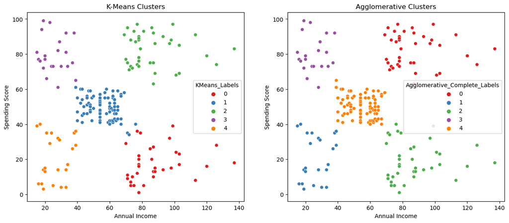

```python
# Comparing K-Means and Agglomerative Clustering Results

# Creating a side-by-side comparison plot

# Setting the figure size for the subplot
plt.figure(figsize=(15, 6))

# Subplot 1: Visualizing K-Means Clusters
plt.subplot(1, 2, 1)
sns.scatterplot(x='Annual_income', y='Spending_score', hue='KMeans_Labels', palette='Set1', data=d_f)
plt.title('K-Means Clusters')
plt.xlabel('Annual Income')
plt.ylabel('Spending Score')

# Subplot 2: Visualizing Agglomerative Clusters
plt.subplot(1, 2, 2)
sns.scatterplot(x='Annual_income', y='Spending_score', hue='Agglomerative_Complete_Labels', palette='Set1', data=d_f)
plt.title('Agglomerative Clusters')
plt.xlabel('Annual Income')
plt.ylabel('Spending Score')

plt.show()
```